# C of I Admission Data Analysis

Author

Rabin, Ashley, Prabin and Tadeo

Published

April 28, 2025

# 1 Introduction

## 1.1 Objective

The primary goal of this analysis is to build a predictive model to estimate whether a prospective student will enroll (`Enrolled`) based on their characteristics and interactions with the college. This can help the admissions office optimize recruitment strategies and resource allocation.

## 1.2 Data Source

The dataset consists of anonymized prospect data for the years 2022-2024, provided by the college’s admissions department. Note: If any individual identification is possible, Dr. Friedlander must be contacted immediately.

## 1.3 Data Description

The dataset contains records for prospective students. Key features include:

- **Prospect**: Was information on this prospect purchased? (Y/N)
- **Inquiry**: Did the student reach out to us first? (Y/N)
- **Applicant**: Did the student apply? (Y/N)
- **Admit**: Was the student admitted? (Y/N)
- **Conversion Rate**: Did the student convert from an admit to a deposit? (Y/N)
- **Deposit**: Did the student put down a deposit? (Y/N)
- **Yield Rate**: Did the student convert from a deposit to an enrolled student? (Y/N)
- **Drops-DP/DF**: Deposits who don’t enroll or defer.
- **Net Deposits**: Deposits that matriculate that fall.
- **Sex**: Sex of student.
- **Student Type**: Freshman or Transfer.
- **IPEDS Classification**: Race category used by IPEDS.
- **Geographic Region**: Region where the student lives.
- **Active County**: County if from Idaho.
- **First_Source Origin**: Where the prospect data was initially obtained.
- **First Source Summary**: Summary of the first source.
- **Application Source**: How the student submitted their application.
- **Entry Term**: Intended matriculation term.
- **School X Type**: Type of school X on their application.
- **School X Institution**: Name of school X on their application.
- **School X Verified GPA**: GPA from school X.
- **ACT and SAT variables**: Standardized test scores.
- **Sport X Sport**: Sport interest.
- **Academic Interest**: Stated academic interest.
- **Enrolled**: Target variable created during data cleaning, indicating if the student ultimately enrolled (1 for enrolled, 0 for not enrolled).

The primary task involves cleaning, augmenting, and feature engineering this data to predict the `Enrolled` status based on predictors like `Sex`, `Student Type`, `IPEDS Classification`, `Geographic Region`, `GPA`, test scores, and academic/sport interests.

# 2 Data Preparation

## 2.1 Loading & Cleaning the Data

```r
Fall2022Data <- read.csv("Fall2022Data.csv")
Fall2023Data <- read.csv("Fall2023Data.csv")
Fall2024Data <- read.csv("Fall2024Data.csv")

Fall2022Data <- Fall2022Data |>
  mutate(origin = "Fall2022Data")

Fall2023Data <- Fall2023Data |>
  mutate(origin = "Fall2023Data")

Fall2024Data <- Fall2024Data |>
  mutate(origin = "Fall2024Data")

FallData <- bind_rows(Fall2022Data, Fall2023Data, Fall2024Data)

FallData <- FallData |>
  mutate(across(where(is.character), as.factor))


FallData$School..1.Verified.GPA <- ifelse(FallData$School..1.Verified.GPA > 5,
                                          FallData$School..1.Verified.GPA / 100 * 4,
                                          FallData$School..1.Verified.GPA)

FallData$School..2.Verified.GPA <- ifelse(FallData$School..2.Verified.GPA > 5,
                                          FallData$School..2.Verified.GPA / 100 * 4,
                                          FallData$School..2.Verified.GPA)

FallData$School..3.Verified.GPA <- ifelse(
  FallData$School..3.Verified.GPA == 4317,
  FallData$School..3.Verified.GPA / 1000,
  FallData$School..3.Verified.GPA)

FallData$School..3.Verified.GPA <- ifelse(FallData$School..3.Verified.GPA > 5,
                                          FallData$School..3.Verified.GPA / 100 * 4,
                                          FallData$School..3.Verified.GPA)
```

```r
# Find the index of the Applicant column
applicant_idx <- which(names(FallData) == "Applicant")

# Filter rows where "Y" appears in Applicant or any column to the right
FallData_filtered <- FallData |>
  filter(apply(
    FallData[, applicant_idx:ncol(FallData)], 1,
    function(row) any(row == "Y")
  ))

admit_idx <- which(names(FallData_filtered) == "Yield.Rate")

Enrolled_FallData <- FallData_filtered |>
  mutate(
    Enrolled = apply(
      FallData_filtered, 1, function(row) {
        # Check if any "Y" in Yield Rate or right of Yield Rate
        any_right = any(row[(admit_idx):(ncol(FallData_filtered))] == "Y", na.rm = TRUE)
        # Check if any "Y" in left of Yield Rate
        any_left = any(row[1:(admit_idx-1)] == "Y", na.rm = TRUE)
        if (isTRUE(any_right)) {
          return(1)
        } else if (isTRUE(any_left)) {
          return(0)
        } else {
          return(NA)
        }
      }
    )
  )

head(Enrolled_FallData)
```

|  | Prospect | Inquiry | Applicant | Admit | Conversion.Rate | Deposit | Yield.Rate | Drops.DP.DF | Defers | Net.Deposits | Sex | Student.Type | IPEDS.Classification | Geographic.Region | Active.Region | Active.County | First_Source.Origin.First.Source.Summary | Application.Source | Entry.Term | School.1.Type | School.1.Institution | School..1.Verified.GPA | School.2.Institution | School.2.Type | School..2.Verified.GPA | School.3.Institution | School.3.Type | School..3.Verified.GPA | School.4.Institution | … |
| --- | --- | --- | --- | --- | --- | --- | --- | --- | --- | --- | --- | --- | --- | --- | --- | --- | --- | --- | --- | --- | --- | --- | --- | --- | --- | --- | --- | --- | --- | --- |
| 1 | N | Y | N | N | N | N | N | N | N | Y | F | Freshman | Nonresident Alien | International | Rare | NA | SAT R | Slate | Fall 2022 | H | Rare | NA | aac4014d574fb11fd74124181324d6a7 | H | NA | 72a2e2e93e428911bf010448ea283692 | NA | NA | NA | … |
| 2 | N | Y | N | Y | Y | N | Y | N | N | Y | F | Freshman | Nonresident Alien | International | Rare | NA | Common App-Prospect Import | Common App | Fall 2022 | H | Rare | 3.90 | NA | NA | NA | NA | NA | NA | NA | … |
| 3 | N | Y | N | Y | Y | N | Y | N | N | Y | M | Freshman | African American or Black | Idaho | ID | Ada | Apply Idaho | Apply Idaho | Fall 2022 | H | capital high school | 4.21 | NA | NA | NA | NA | NA | NA | NA | … |
| 4 | N | Y | N | N | Y | N | Y | N | N | Y | M | Freshman | Nonresident Alien | International | Rare | NA | Common App- Suspect Import | Common App | Fall 2022 | H | Rare | NA | NA | NA | NA | NA | NA | NA | NA | … |
| 5 | N | Y | N | N | Y | N | Y | N | N | Y | F | Freshman | Asian | Idaho | ID | Ada | Apply Idaho | Apply Idaho | Fall 2022 | H | rocky mountain high school | 2.67 | NA | NA | NA | NA | NA | NA | NA | … |
| 6 | N | Y | N | Y | Y | N | Y | N | N | Y | F | Freshman | African American or Black | Idaho | ID | Ada | Apply Idaho | Apply Idaho | Fall 2022 | H | capital high school | 3.75 | NA | NA | NA | NA | NA | NA | NA | … |

## 2.2 Exploratory Data Analysis (EDA)

We calculate what percentage of total prospects make it to each stage in the admissions funnel: from Prospect → Applicant → Admit → Deposit → Enrolled. This provides a snapshot of how many students move forward at each stage and where the most significant drop-offs occur.

```r
# Total number of students
total_students <- nrow(FallData)

# Funnel stage counts
funnel_counts <- c(
  Prospect = sum(FallData$Prospect == "Y", na.rm = TRUE),
  Applicant = nrow(FallData_filtered),
  Admit = sum(FallData$Admit == "Y", na.rm = TRUE),
  Deposit = sum(FallData$Deposit == "Y", na.rm = TRUE),
  Enrolled = sum(Enrolled_FallData$Enrolled == 1, na.rm = TRUE)
)

# Funnel stage percentages
funnel_percentages <- round((funnel_counts / total_students) * 100, 2)

# summary table
funnel_summary <- data.frame(
  Count = funnel_counts,
  Percentage = paste0(funnel_percentages, "%")
)

kable(funnel_summary, caption = "Funnel Stage Conversion Rates (Counts & %)", align = "c")
```

Funnel Stage Conversion Rates (Counts & %)

|  | Count | Percentage |
| --- | --- | --- |
| Prospect | 52650 | 48.55% |
| Applicant | 9587 | 8.84% |
| Admit | 6375 | 5.88% |
| Deposit | 1085 | 1% |
| Enrolled | 5584 | 5.15% |

The funnel stage analysis revealed significant drop-offs at each step of the admissions process. Out of 108,437 total records, only 48.55% were identified as prospects, and just 8.84% applied. From there, 5.88% were admitted, 1.00% deposited, and 5.15% ultimately enrolled. The largest drop occurred between prospects and applicants, followed by admitted students who did not deposit. Interestingly, more students were marked as enrolled than deposited, suggesting either data inconsistencies or alternative enrollment pathways. These patterns highlight key areas for improving outreach, engagement, and data tracking across the admissions funnel.

We then created an `Enrolled` variable by scanning for a “Y” response in the `Yield Rate` column or beyond. This helped us classify students who ultimately enrolled.

```r
# Finding the index of the Yield Rate column
admit_idx <- which(names(FallData) == "Yield.Rate")

# Created Enrolled column
FallData <- FallData |>
  mutate(
    Enrolled = apply(FallData, 1, function(row) {
      any_right = any(row[(admit_idx):(ncol(FallData))] == "Y", na.rm = TRUE)
      any_left = any(row[1:(admit_idx - 1)] == "Y", na.rm = TRUE)
      if (isTRUE(any_right)) {
        return(1)
      } else if (isTRUE(any_left)) {
        return(0)
      } else {
        return(NA)
      }
    })
  )
```

### 2.2.1 Enrollment by Sex

We examined how enrollment rates vary between male and female students. Female students had a slightly higher enrollment rate than males, while students with unknown sex had a significantly lower enrollment rate.

```r
FallData |>
  mutate(Enrolled = factor(Enrolled)) |>
  group_by(Sex, Enrolled) |>
  summarise(count = n()) |>
  pivot_wider(names_from = Enrolled, values_from = count, values_fill = 0) |>
  mutate(total = `0` + `1`, enrolled_percent = round(`1` / total * 100, 2))
```

| Sex | 0 | 1 | total | enrolled_percent |
| --- | --- | --- | --- | --- |
| F | 55284 | 3244 | 58528 | 5.54 |
| M | 42337 | 2290 | 44627 | 5.13 |
| NA | 5232 | 50 | 5282 | 0.95 |

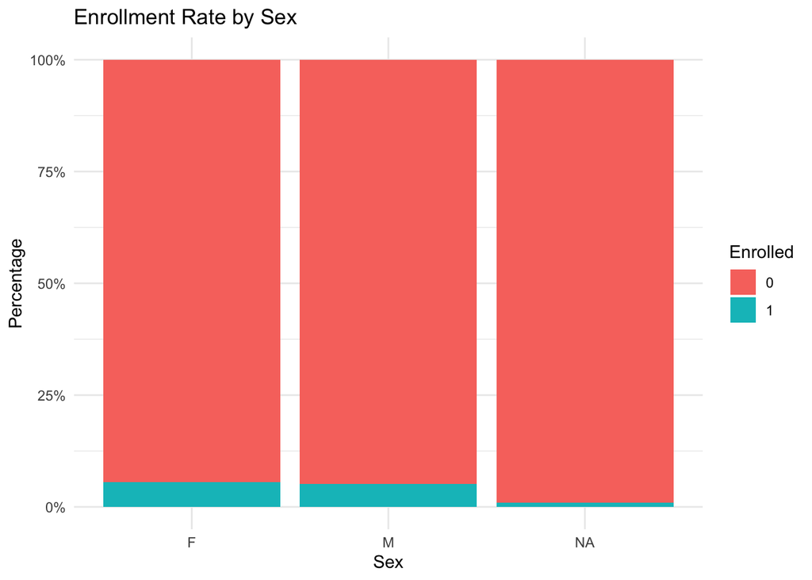

```r
ggplot(FallData, aes(x = Sex, fill = factor(Enrolled))) +
  geom_bar(position = "fill") +
  scale_y_continuous(labels = scales::percent) +
  labs(title = "Enrollment Rate by Sex", y = "Percentage", fill = "Enrolled") +
  theme_minimal()
```

### 2.2.2 Enrollment by Student Type

We compared enrollment between **Freshman** and **Transfer** students. Although the majority of prospects were Freshmen, **Transfer students enrolled at a much higher rate** (over 56%).

```r
FallData |>
  mutate(Enrolled = factor(Enrolled)) |>
  group_by(`Student.Type`, Enrolled) |>
  summarise(count = n()) |>
  pivot_wider(names_from = Enrolled, values_from = count, values_fill = 0) |>
  mutate(total = `0` + `1`, enrolled_percent = round(`1` / total * 100, 2))
```

| Student.Type | 0 | 1 | total | enrolled_percent |
| --- | --- | --- | --- | --- |
| Freshman | 102025 | 4516 | 106541 | 4.24 |
| Transfer | 828 | 1068 | 1896 | 56.33 |

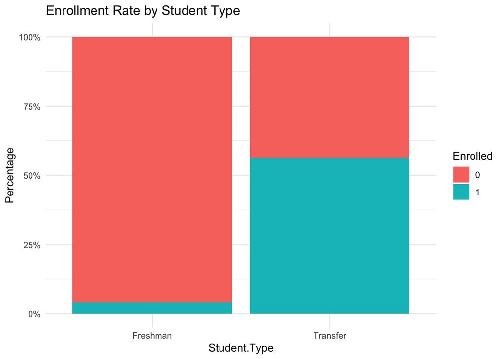

```r
ggplot(FallData, aes(x = Student.Type, fill = factor(Enrolled))) +
  geom_bar(position = "fill") +
  scale_y_continuous(labels = scales::percent) +
  labs(title = "Enrollment Rate by Student Type", y = "Percentage", fill = "Enrolled") +
  theme_minimal()
```

### 2.2.3 Enrollment by Sport Interest

```r
FallData |>
  mutate(Enrolled = factor(Enrolled)) |>
  group_by(`Sport.1.Sport`, Enrolled) |>
  summarise(count = n()) |>
  pivot_wider(names_from = Enrolled, values_from = count, values_fill = 0) |>
  mutate(total = `0` + `1`, enrolled_percent = round(`1` / total * 100, 2)) |>
  arrange(desc(`1`))
```

| Sport.1.Sport | 0 | 1 | total | enrolled_percent |
| --- | --- | --- | --- | --- |
| NA | 100370 | 4581 | 104951 | 4.36 |
| 8977f96e5ee90d6a516b07a78d81bf3e | 442 | 204 | 646 | 31.58 |
| f26eb1b8888482851a6d9ea80a85b995 | 327 | 183 | 510 | 35.88 |
| 27ebe73655ad1ade6a1837b29d421a61 | 152 | 93 | 245 | 37.96 |
| ce0b7200e6b5795c667a13fc9d6ab807 | 161 | 63 | 224 | 28.12 |
| d0fc5379ab968347a47c9b1d30104aa8 | 154 | 56 | 210 | 26.67 |
| 6456c36f8bbd5cc1d64c24af30739671 | 165 | 55 | 220 | 25.00 |
| e6a3329faa1d49f0ff471465125a2093 | 105 | 55 | 160 | 34.38 |
| b93c00ac186f8d7175fb993b534496d2 | 132 | 53 | 185 | 28.65 |
| 094de381f6df6eb69440ec54bc716ead | 137 | 49 | 186 | 26.34 |

[output cut: 10 more lines]

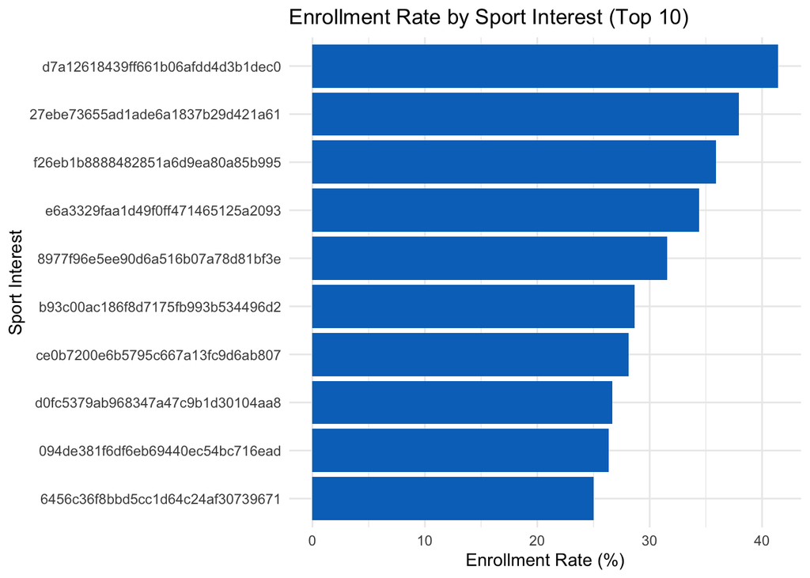

```r
sport_plot_data <- FallData |>
  mutate(Enrolled = factor(Enrolled)) |>
  group_by(`Sport.1.Sport`, Enrolled) |>
  summarise(count = n(), .groups = "drop") |>
  pivot_wider(names_from = Enrolled, values_from = count, values_fill = 0) |>
  mutate(
    total = `0` + `1`,
    enrolled_percent = round(`1` / total * 100, 2)
  ) |>
  arrange(desc(`1`)) |>
  filter(!is.na(`Sport.1.Sport`)) |>
  slice_max(`1`, n = 10)

# Plot
ggplot(sport_plot_data, aes(x = reorder(`Sport.1.Sport`, enrolled_percent), y = enrolled_percent)) +
  geom_col(fill = "#0073C2FF") +
  coord_flip() +
  labs(
    title = "Enrollment Rate by Sport Interest (Top 10)",
    x = "Sport Interest",
    y = "Enrollment Rate (%)"
  ) +
  theme_minimal()
```